# MTH6139 Time Series

Coursework1_210447129

Omid Ashoorzada

March 2024

## What is the purpose of this project?

The purpose of this projects is to analyse the Co2 time series. We would like to know if the data has a specific trend and seasonality. Meta’s prophet tool allows us to forecast from the previous data.

## What is Co2?

The Co2 is a dataset representing the atmospheric Co2 concentrations measured in parts per million at the Observatory. The data collected is from January 1959 to December 1997 and there are 468 observations. To find the total number of observations I used the following code

TotalObservations <- length(co2)

print(TotalObservations)

which should give 468 observations.

## Plotting the time series

This loads the `prophet` package in R which will be needed for forecasting.

```r
library("prophet")
```

This line creates a data frame from Co2 time series so we can use this for the Prophet tool.

```r
co2.df = data.frame(
  ds=zoo::as.yearmon(time(co2)),
  y=co2)
```

```r
co2Model = prophet::prophet(co2.df,yearly.seasonality = TRUE, weekly.seasonality = TRUE,daily.seasonality = TRUE)
```

## Future Values

The `FutureDates` variable creates a dataframe with 24 periods ahead from the last date in the co2 times series (which is December 1997). The `FutureDates` is from December 1997 to December 1999. The dates will be used to forecast the co2.

```r
FutureDates = prophet::make_future_dataframe(co2Model, periods=24, freq="month")
```

`predict` will forecast the values for the future dates.

```r
ForecastPrediction = predict(co2Model, FutureDates)
```

This will display the last 6 rows of the predicted data. `ds` is the data, `yhat` is the forecasted value, `yhat_lower` is the lower bound and lastly `yhat_upper` is the upper bound.

```r
tail(ForecastPrediction[c('ds', 'yhat', 'yhat_lower', 'yhat_upper')])
```

```
##             ds     yhat yhat_lower yhat_upper
## 487 1999-07-01 367.2992   366.5863   368.0375
## 488 1999-08-01 365.4482   364.6628   366.2102
## 489 1999-09-01 363.6824   362.8890   364.4535
## 490 1999-10-01 363.5055   362.5868   364.3261
## 491 1999-11-01 364.9318   364.0744   365.8057
## 492 1999-12-01 366.1155   365.2301   367.0903
```

## Plot

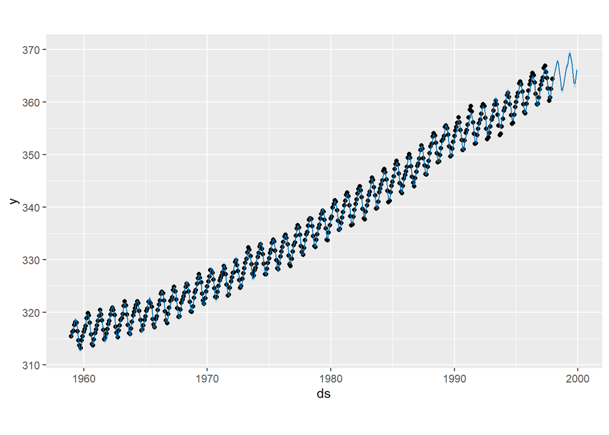

```r
plot(co2Model, ForecastPrediction)
```

## Dyplot

Here is an interactive graph. You can interact with the graph to see the level of Co2 each month for the predicted and the actual values. You get to also see the upper and lower bound of the graph when you zoom in. This make it much easier to understand and read the graph.

```r
dyplot.prophet(co2Model, ForecastPrediction)
```

[interactive chart not shown]

## Changepoint

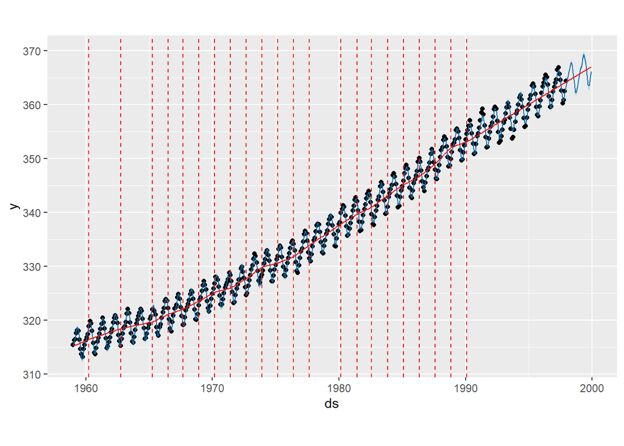

```r
plot(co2Model, ForecastPrediction) + add_changepoints_to_plot(co2Model)
```

The red dashed lines show change points on the graph where the trend significantly changes and the red line shows the line of best fit.

## Trend and Seasonality

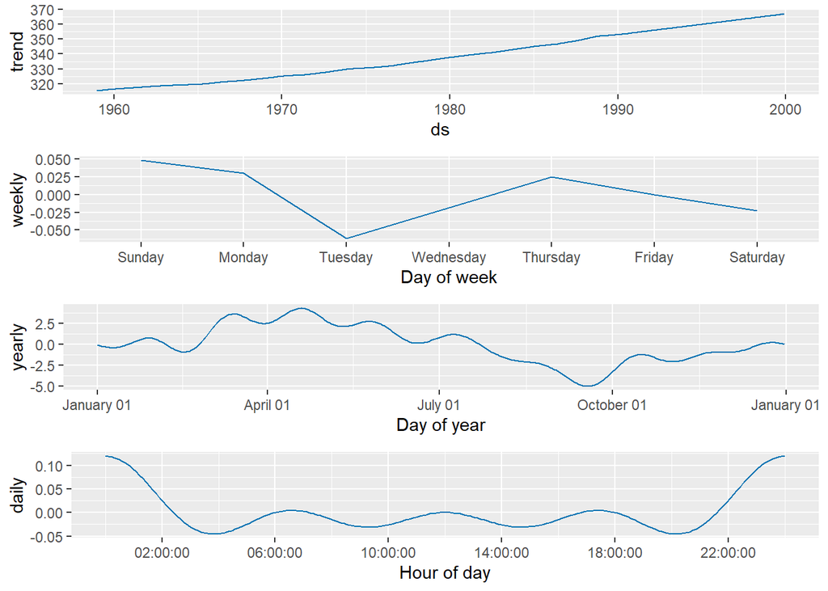

```r
prophet_plot_components(co2Model, ForecastPrediction)
```

From the first graph we can clearly see a trend. There is a positive correlation between the Co2 concentration and the year increase. This shows that the level of co2 is increasing steadily.

For the weekly, there appears to be a slight pattern. From Sunday (the highest in the week) to Tuesday (the lowest in the week) the pattern decreases, Tuesday to Thursdays it increases. After Thursday it decreases.

For the yearly seasonality graph, we can see that there are high levels of Co2 emissions from March to June (the highest peak on the graph). The lowest month of Co2 emissions is just before October.

Lastly, on the last graph we can see there is a similar trend from 4am to 8 pm. After 8pm it increases.